# Covariance vs. Correlation

Louis Sirugue

09/2021

### 1. Setup

Consider the following two distributions:

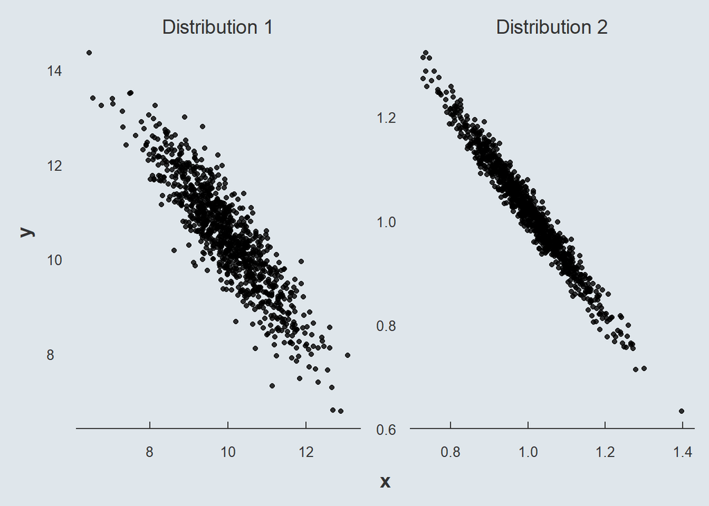

```r
x <- rnorm(1000, 10, 1)
y <- (-x+20) - rnorm(1000, -.5, .5)
x2 <- rnorm(1000, 1, .1)
y2 <- (-x2+2) - rnorm(1000, -.02, .02)

example <- tibble(x = c(x, x2), y = c(y, y2),
                  z = rep(paste("Distribution", 1:2), each = 1000))

ggplot(example, aes(x = x, y = y)) +
  geom_point(alpha = .8) + facet_wrap(~z, scales = "free")
```

We would like to quantify the strength of these two relationships with

**The covariance:**

$$\text{Cov}(x, y) = \frac{1}{N}\sum_{i=1}^{N}(x_i − \bar{x})(y_i − \bar{y})$$

**The correlation:**

$$\text{Corr}(x, y) = \frac{\text{Cov}(x, y)}{\text{SD}(x)\times\text{SD}(y)}$$

### 2. Sign of the relationship

In our case when $x$ is below its average, $y$ tends to be above its average (opposite sign of the two terms: negative contribution to the covariance), and when $x$ is above its average, $y$ tends to be below its average (opposite sign of the two terms: negative contribution to the covariance). Thus the **covariance**, and consequently the **correlation** (standard deviations are always positive by definition), will be **negative**.

### 3. Strength of the relationship

The **covariance** can take values from $-\infty$ to $+\infty$, and its distance to 0 **will depend** both on the **strength** of the relationship and on the **order of magnitude** of the values taken by the two variables.

The **correlation** *‘’rescales’’* the covariance: dividing the covariance by the standard deviations of the two variables gives a value comprised between $-1$ and $1$. Thus, it **only depends** on the **strength** of the relationship.

In our case, because the variables of the first relationship take larger values than the variables of the second relationship (compare the axes), the (absolute) covariance is greater for the first relationship even though we can see visually that the second relationship is stronger. This is why we cannot compare covariances directly. But the correlation rescales the statistics so that they can be comparable, and indeed captures that the second relationship is stronger:

```r
kable(tibble(Statistic = c("cov(x, y)", "sd(x)*sd(y)", "cor(x, y)"),
             `Distribution 1` = c(cov(x, y), sd(x)*sd(y), cor(x, y)),
             `Distribution 2` = c(cov(x2, y2), sd(x2)*sd(y2), cor(x2, y2))),
      caption = "Comparing the distributions")
```

Comparing the distributions

| Statistic | Distribution 1 | Distribution 2 |
| --- | --- | --- |
| cov(x, y) | -0.9990 | -0.0102 |
| sd(x)*sd(y) | 1.1166 | 0.0104 |
| cor(x, y) | -0.8947 | -0.9819 |